# L02 Data Transformation

Data Science 1 with R (STAT 301-1)

Author

Olivia Allen

Published

October 13, 2024

**Github Repo Link✅**

https://github.com/stat301-1-2024-fall/L02-data-transformations-oliviaallen2003.git

## Load packages ✅

```r
# Loading package(s)
library(tidyverse)
library(dplyr)
library(knitr)
library(kableExtra)

# load data
college_rankings <- read_csv("data/college_rankings.csv")
college_rankings_codebook <- read_csv("data/college_rankings_codebook.csv")

tinder_data <- read_csv("data/tinder_data.csv")
tinder_data_codebook <- read_csv("data/tinder_data_codebook.csv")
```

## Exercises

### Exercise 1✅

Using a single pipeline operator ( `|>` or `%>%` ), find all colleges that:

1. Had a tuition greater than $50,000
2. Are located in Illinois and ranked in the top 50
3. have a median ACT score greater than 32 or mean SAT score greater than 1430
4. have a median ACT score greater than 32 or mean SAT score greater than 1430 AND are ranked in the top 50

**Solution**

```r
# a. Had a tuition greater than $50,000
college_rankings |>
  filter(tuition_fees > 50000) |>
  relocate(institution, tuition_fees)
```

```
# A tibble: 122 × 29
   institution       tuition_fees unitid fed_sch_code state_abbr city  rank_2023
   <chr>                    <dbl>  <dbl> <chr>        <chr>      <chr>     <dbl>
 1 California Colle…        51092 110370 1127         CA         San …       376
 2 California Insti…        54600 110404 1131         CA         Pasa…         7
 3 California Insti…        51466 111081 1132         CA         Vale…       197
 4 Chapman Universi…        54924 111948 1164         CA         Oran…       158
 5 Claremont McKenn…        56475 112260 1170         CA         Clar…        34
 6 Loyola Marymount…        50283 117946 1234         CA         Los …        90
 7 Occidental Colle…        56576 120254 1249         CA         Los …        95
 8 Pepperdine Unive…        55892 121150 1264         CA         Mali…       175
 9 Pitzer College           56018 121257 1172         CA         Clar…        88
10 Pomona College           54762 121345 1173         CA         Clar…        25
# ℹ 112 more rows
# ℹ 22 more variables: public <chr>, room_board <dbl>, avg_net_price <dbl>,
#   salary_after_10 <dbl>, overall_score <dbl>, resources_score <dbl>,
#   engagement_score <dbl>, outcomes_score <dbl>, environment_score <dbl>,
#   accept_rate <dbl>, act_median <dbl>, sat_avg <dbl>, ug_enrolled <dbl>,
#   grad_enrolled <dbl>, retention_rate <dbl>, ug_student_loan_pct <dbl>,
#   ug_men_pct <dbl>, ug_women_pct <dbl>, student_faculty_ratio <dbl>, …
```

```r
# b. Are located in Illinois and ranked in the top 50
college_rankings |>
  filter(state_abbr == "IL",
         rank_2023 <= 50) |>
  relocate(institution, rank_2023, state_abbr) |>
  arrange(rank_2023)
```

```
# A tibble: 3 × 29
  institution rank_2023 state_abbr unitid fed_sch_code city  public tuition_fees
  <chr>           <dbl> <chr>       <dbl> <chr>        <chr> <chr>         <dbl>
1 Northweste…         9 IL         147767 1739         Evan… priva…        56691
2 The Univer…        14 IL         144050 1774         Chic… priva…        59298
3 University…        45 IL         145637 1775         Cham… public        36213
# ℹ 21 more variables: room_board <dbl>, avg_net_price <dbl>,
#   salary_after_10 <dbl>, overall_score <dbl>, resources_score <dbl>,
#   engagement_score <dbl>, outcomes_score <dbl>, environment_score <dbl>,
#   accept_rate <dbl>, act_median <dbl>, sat_avg <dbl>, ug_enrolled <dbl>,
#   grad_enrolled <dbl>, retention_rate <dbl>, ug_student_loan_pct <dbl>,
#   ug_men_pct <dbl>, ug_women_pct <dbl>, student_faculty_ratio <dbl>,
#   faculty_full_time_pct <dbl>, faculty_women_pct <dbl>, …
```

```r
# c. have a median ACT score greater than 32 or mean SAT score greater than 1430
college_rankings |>
  filter(act_median > 32 | sat_avg > 1430) |>
  relocate(institution, act_median, sat_avg)
```

```
# A tibble: 54 × 29
   institution act_median sat_avg unitid fed_sch_code state_abbr city  rank_2023
   <chr>            <dbl>   <dbl>  <dbl> <chr>        <chr>      <chr>     <dbl>
 1 Claremont …         34    1487 112260 1170         CA         Clar…        34
 2 Pomona Col…         34    1520 121345 1173         CA         Clar…        25
 3 Scripps Co…         33    1456 123165 1174         CA         Clar…        67
 4 University…         34    1484 123961 1328         CA         Los …        19
 5 Wesleyan U…         33    1426 130697 1424         CT         Midd…        43
 6 Yale Unive…         34    1526 130794 1426         CT         New …         4
 7 Georgetown…         34    1488 131496 1445         DC         Wash…        32
 8 Emory Univ…         33    1480 139658 1564         GA         Atla…        20
 9 The Univer…         34    1535 144050 1774         IL         Chic…        14
10 Northweste…         35    1529 147767 1739         IL         Evan…         9
# ℹ 44 more rows
# ℹ 21 more variables: public <chr>, tuition_fees <dbl>, room_board <dbl>,
#   avg_net_price <dbl>, salary_after_10 <dbl>, overall_score <dbl>,
#   resources_score <dbl>, engagement_score <dbl>, outcomes_score <dbl>,
#   environment_score <dbl>, accept_rate <dbl>, ug_enrolled <dbl>,
#   grad_enrolled <dbl>, retention_rate <dbl>, ug_student_loan_pct <dbl>,
#   ug_men_pct <dbl>, ug_women_pct <dbl>, student_faculty_ratio <dbl>, …
```

```r
# d. have a median ACT score greater than 32 or mean SAT score greater than 1430 AND are ranked in the top 50
college_rankings |>
  filter(act_median > 32 | sat_avg > 1430, rank_2023 <= 50) |>
  relocate(institution) |>
  arrange(rank_2023)
```

```
# A tibble: 34 × 29
   institution             unitid fed_sch_code state_abbr city  rank_2023 public
   <chr>                    <dbl> <chr>        <chr>      <chr>     <dbl> <chr>
 1 Harvard University      166027 2155         MA         Camb…         1 priva…
 2 Stanford University     243744 1305         CA         Stan…         2 priva…
 3 Yale University         130794 1426         CT         New …         4 priva…
 4 Duke University         198419 2920         NC         Durh…         5 priva…
 5 Brown University        217156 3401         RI         Prov…         6 priva…
 6 Princeton University    186131 2627         NJ         Prin…         8 priva…
 7 Northwestern University 147767 1739         IL         Evan…         9 priva…
 8 Cornell University      190415 2711         NY         Itha…        11 priva…
 9 University of Pennsylv… 215062 3378         PA         Phil…        12 priva…
10 Dartmouth College       182670 2573         NH         Hano…        13 priva…
# ℹ 24 more rows
# ℹ 22 more variables: tuition_fees <dbl>, room_board <dbl>,
#   avg_net_price <dbl>, salary_after_10 <dbl>, overall_score <dbl>,
#   resources_score <dbl>, engagement_score <dbl>, outcomes_score <dbl>,
#   environment_score <dbl>, accept_rate <dbl>, act_median <dbl>,
#   sat_avg <dbl>, ug_enrolled <dbl>, grad_enrolled <dbl>,
#   retention_rate <dbl>, ug_student_loan_pct <dbl>, ug_men_pct <dbl>, …
```

### Exercise 2✅

Find the colleges ranked 2, 3, and 4 in 3 different ways:

1. using the “or” operator
2. using `%in%`
3. using `between()`

**Solution**

```r
# 1. using the "or" operator
college_rankings |>
  filter(rank_2023 == 2 | rank_2023 == 3 | rank_2023 == 4) |>
  select(institution, rank_2023) |>
  arrange(rank_2023)
```

```
# A tibble: 3 × 2
  institution                           rank_2023
  <chr>                                     <dbl>
1 Stanford University                           2
2 Massachusetts Institute of Technology         3
3 Yale University                               4
```

```r
# 2. using `%in%`
college_rankings |>
  filter(rank_2023 %in% c(2, 3, 4)) |>
  select(institution, rank_2023) |>
  arrange(rank_2023)
```

```
# A tibble: 3 × 2
  institution                           rank_2023
  <chr>                                     <dbl>
1 Stanford University                           2
2 Massachusetts Institute of Technology         3
3 Yale University                               4
```

```r
# 3. Using `between()`
college_rankings |>
  filter(between(rank_2023, 2, 4)) |>
  select(institution, rank_2023) |>
  arrange(rank_2023)
```

```
# A tibble: 3 × 2
  institution                           rank_2023
  <chr>                                     <dbl>
1 Stanford University                           2
2 Massachusetts Institute of Technology         3
3 Yale University                               4
```

### Exercise 3✅

Was a college from every state ranked in this data frame?

**Solution**

```r
college_rankings |>
  distinct(state_abbr)
```

```
# A tibble: 50 × 1
   state_abbr
   <chr>
 1 AL
 2 AZ
 3 AR
 4 CA
 5 CO
 6 CT
 7 DE
 8 DC
 9 FL
10 GA
# ℹ 40 more rows
```

```r
college_rankings |>
  distinct(state_abbr) |>
  pull(state_abbr) |>
  setdiff(state.abb)
```

```
[1] "DC"
```

Although there are 50 distinct values displayed, the data set counted DC as a state when it is not a state. Additionally, Alaska is missing from the printed list. Thus, there is not a college from every state.

### Exercise 4✅

1. Arrange the data to find the most expensive colleges.
2. Use the slice function to select the 5 most expensive colleges.

**Solution**

```r
# a. Arrange the data to find the most expensive colleges
college_rankings |>
  arrange(desc(tuition_fees)) |>
  select(institution, tuition_fees, rank_2023)
```

```
# A tibble: 796 × 3
   institution                 tuition_fees rank_2023
   <chr>                              <dbl>     <dbl>
 1 Columbia University                60578        16
 2 The University of Chicago          59298        14
 3 Trinity College                    59050       104
 4 Franklin & Marshall College        58800        84
 5 Vassar College                     58770        65
 6 Amherst College                    58640        22
 7 Tufts University                   58578        30
 8 Kenyon College                     58480        93
 9 Reed College                       58440        92
10 Brown University                   58404         6
# ℹ 786 more rows
```

```r
# b. Use the slice function to select the 5 most expensive colleges
college_rankings |>
  arrange(desc(tuition_fees)) |>
  select(institution, tuition_fees, rank_2023) |>
  slice(1:5)
```

```
# A tibble: 5 × 3
  institution                 tuition_fees rank_2023
  <chr>                              <dbl>     <dbl>
1 Columbia University                60578        16
2 The University of Chicago          59298        14
3 Trinity College                    59050       104
4 Franklin & Marshall College        58800        84
5 Vassar College                     58770        65
```

### Exercise 5✅

Create a variable called `avg_financial_aid` which is calculated as the cost of attendance (tuition, fees, room and board) minus the average net price. **ONLY** include the institution and relevant variables in the printed output.

**Solution**

```r
college_rankings |>
  mutate(avg_financial_aid = tuition_fees, room_board - avg_net_price) |>
  select(institution, tuition_fees, avg_net_price, avg_financial_aid, room_board)
```

```
# A tibble: 796 × 5
   institution           tuition_fees avg_net_price avg_financial_aid room_board
   <chr>                        <dbl>         <dbl>             <dbl>      <dbl>
 1 University of Alabam…        20400         16585             20400      12307
 2 University of Alabam…        23518         17250             23518      10400
 3 The University of Al…        30250         21534             30250      13636
 4 Auburn University            31124         23258             31124      13600
 5 University of Montev…        26728         17348             26728       9810
 6 Samford University           32850         30716             32850      10980
 7 University of South …        16292         16223             16292       7800
 8 Tuskegee University          22614         34926             22614       9844
 9 Arizona State Univer…        29428         12814             29428      13164
10 University of Arizona        34662         15601             34662      13050
# ℹ 786 more rows
```

### Exercise 6✅

What happens if you specify the name of the same variable multiple times in a `select()` call?

**Solution**

```r
college_rankings |>
  select(institution, tuition_fees, avg_net_price, tuition_fees)
```

```
# A tibble: 796 × 3
   institution                         tuition_fees avg_net_price
   <chr>                                      <dbl>         <dbl>
 1 University of Alabama at Birmingham        20400         16585
 2 University of Alabama in Huntsville        23518         17250
 3 The University of Alabama                  30250         21534
 4 Auburn University                          31124         23258
 5 University of Montevallo                   26728         17348
 6 Samford University                         32850         30716
 7 University of South Alabama                16292         16223
 8 Tuskegee University                        22614         34926
 9 Arizona State University (Tempe)           29428         12814
10 University of Arizona                      34662         15601
# ℹ 786 more rows
```

There is no error produced by R when you specify the name of the same variable multiple times in a `select()` call. R will not duplicate the column in the output, it just included the column once. For example, in the code above, I specified the variable “tuition_fees” twice in the ‘select()’ call but it was only included once in the output.

### Exercise 7✅

Use the following vector in conjunction with `any_of()` to select the specified variables from the data frame.

```r
# list of variables
variables <- c("institution", "state", "rank_2023", "overall_score")
```

**Solution**

```r
college_rankings |>
  select(any_of(variables))
```

```
# A tibble: 796 × 3
   institution                         rank_2023 overall_score
   <chr>                                   <dbl>         <dbl>
 1 University of Alabama at Birmingham       306          52.9
 2 University of Alabama in Huntsville       401          48.2
 3 The University of Alabama                 401          48.2
 4 Auburn University                         284          54
 5 University of Montevallo                  601          37.2
 6 Samford University                        184          59
 7 University of South Alabama               601          37.2
 8 Tuskegee University                       401          48.2
 9 Arizona State University (Tempe)          214          57.1
10 University of Arizona                     131          63.7
# ℹ 786 more rows
```

### Exercise 8✅

Use the `contains()` function to select all scores (overall, resources, engagement, outcomes, environment) and the institution from the data frame.

**Solution**

```r
college_rankings |>
  select(institution, contains("score"))
```

```
# A tibble: 796 × 6
   institution     overall_score resources_score engagement_score outcomes_score
   <chr>                   <dbl>           <dbl>            <dbl>          <dbl>
 1 University of …          52.9            14.6             15.7           16.2
 2 University of …          48.2            NA               NA             16.9
 3 The University…          48.2            NA               16.4           17.6
 4 Auburn Univers…          54              10               17.2           22.7
 5 University of …          37.2            14               NA             NA
 6 Samford Univer…          59              17.8             18.1           21.4
 7 University of …          37.2            NA               NA             NA
 8 Tuskegee Unive…          48.2            16.5             NA             NA
 9 Arizona State …          57.1            14.6             16.8           18.3
10 University of …          63.7            16.2             17             23.5
# ℹ 786 more rows
# ℹ 1 more variable: environment_score <dbl>
```

### Exercise 9✅

Rename the variable `rank_2023` to `rank` and move that column directly after `institution` in the data frame.

**Solution**

```r
college_rankings |>
  rename(rank = rank_2023) |>
  relocate(rank, .after = institution)
```

```
# A tibble: 796 × 29
   unitid fed_sch_code institution     rank state_abbr city  public tuition_fees
    <dbl> <chr>        <chr>          <dbl> <chr>      <chr> <chr>         <dbl>
 1 100663 1052         University of…   306 AL         Birm… public        20400
 2 100706 1055         University of…   401 AL         Hunt… public        23518
 3 100751 1051         The Universit…   401 AL         Tusc… public        30250
 4 100858 1009         Auburn Univer…   284 AL         Aubu… public        31124
 5 101709 1004         University of…   601 AL         Mont… public        26728
 6 102049 1036         Samford Unive…   184 AL         Birm… priva…        32850
 7 102094 1057         University of…   601 AL         Mobi… public        16292
 8 102377 1050         Tuskegee Univ…   401 AL         Tusk… priva…        22614
 9 104151 1081         Arizona State…   214 AZ         Tempe public        29428
10 104179 1083         University of…   131 AZ         Tucs… public        34662
# ℹ 786 more rows
# ℹ 21 more variables: room_board <dbl>, avg_net_price <dbl>,
#   salary_after_10 <dbl>, overall_score <dbl>, resources_score <dbl>,
#   engagement_score <dbl>, outcomes_score <dbl>, environment_score <dbl>,
#   accept_rate <dbl>, act_median <dbl>, sat_avg <dbl>, ug_enrolled <dbl>,
#   grad_enrolled <dbl>, retention_rate <dbl>, ug_student_loan_pct <dbl>,
#   ug_men_pct <dbl>, ug_women_pct <dbl>, student_faculty_ratio <dbl>, …
```

### Exercise 10✅

Do public or private schools on average have a higher tuition, overall score, acceptance rate, and undergraduate enrollment? It would also be useful to have the count of the number of public and private schools in this summary.

**Solution**

```r
college_rankings |>
  summarise(
    across(where(is.numeric), \(x) mean(x, na.rm = TRUE)),
    n = n(),
    .by = public
  ) |>
 select(public, tuition_fees, overall_score, accept_rate, ug_enrolled, n)
```

```
# A tibble: 3 × 6
  public  tuition_fees overall_score accept_rate ug_enrolled     n
  <chr>          <dbl>         <dbl>       <dbl>       <dbl> <int>
1 public        23779.          47.5      0.776       14494.   336
2 private       42060.          54.9      0.659        3345.   454
3 <NA>          28964           53.1      0.0956       3041.     6
```

In terms of number of institutions, there are 336 public schools and 454 private schools in the data. Private schools have higher tuition, with an average of $42,059.94 compared to $23,778.96 for public schools. Private schools also have a higher average overall score of 54.86 than public schools with 47.52 as the overall score. Public schools have a higher acceptance rate, averaging 77.58%, while public schools have 65.86%. Public schools enroll more students on average, 14,493.86 than private schools who average 3,345.

### Exercise 11✅

You have a hypothetical dataset, `data`, with numeric variables `x`, `y`, `z` and categorical variable `c`.

What is wrong with the following code? Then fix it to accomplish the goal.

1. You are interested in calculating the average of `x`, `y`, and `z`.
2. You are interested in calculating the average of `x` by `c` and arranging from high to low.

**Solution**

```r
# pseudo code
data |>
  summarize(
    mean = mean(x),
    mean = mean(y),
    mean = mean(z)
  )

# fixed code
data |>
  summarize(
    mean_x = mean(x),
    mean_y = mean(y),
    mean_z = mean(z)
  )
```

The issue with the code is that it uses the same name ‘mean’ for all three summary statistics. The code will likely overwrite each time the mean is calculated and only produce the mean of z. I fixed the code by giving each mean a unique name related to the name of the variable. Now the code will return 3 different means, as opposed to one.

```r
# pseudo code
data |>
  group_by(c) |>
  summarize(mean(x)) |>
  arrange(desc(x))

# fixed code
data |>
  group_by(c) |>
  summarize(mean_x = mean(x)) |>
  arrange(desc(mean_x))
```

The issue with this code is that it didn’t assign a name to the mean. To fix this, I named the mean, ‘mean_x’ within the summarize() function. Additionally, the arrange() function is sorting by x when it should be sorting the calculated mean of x. I changed this function to sort the variable ‘mean_x’ to correctly arrange the results from highest to lowest.

### Exercise 12✅

Use `count()` to find the number of institutions ranked within each state. Print the output with the state with the most institutions on top.

**Solution**

```r
college_rankings |>
  count(state_abbr, name = "num_institutions", sort = TRUE)
```

```
# A tibble: 50 × 2
   state_abbr num_institutions
   <chr>                 <int>
 1 NY                       79
 2 PA                       73
 3 CA                       61
 4 MA                       47
 5 OH                       34
 6 TX                       34
 7 IL                       33
 8 MI                       27
 9 MN                       23
10 FL                       22
# ℹ 40 more rows
```

## Case Study✅

**Solution**

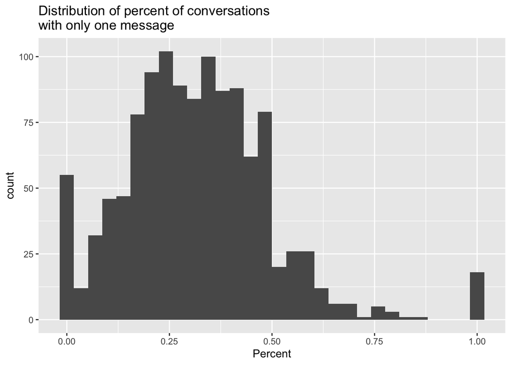

| median | mean | IQR |
| --- | --- | --- |
| 0.308682 | 0.3173404 | 0.2161136 |

Most matches

| Users with the most matches user_birth_date | Users with the most matches user_gender | Users with the most matches matches | Users with the most matches swipes_like |
| --- | --- | --- | --- |
| 1988-03-01T00:00:00Z | M | 23758 | 198373 |
| 1988-03-01T00:00:00Z | M | 22120 | 229162 |
| 1981-05-08T00:00:00Z | M | 16048 | 290148 |
| 1985-06-02T00:00:00Z | F | 14874 | 19449 |
| 1998-01-29T00:00:00Z | M | 13104 | 208304 |

Highest match rate

| Users with the most matches per swipe like user_birth_date | Users with the most matches per swipe like user_gender | Users with the most matches per swipe like matches | Users with the most matches per swipe like swipes_like | Users with the most matches per swipe like match_rate |
| --- | --- | --- | --- | --- |
| 1996-07-24T00:00:00Z | F | 826 | 956 | 0.8640167 |
| 1988-02-12T00:00:00Z | F | 26 | 33 | 0.7878788 |
| 1997-10-03T00:00:00Z | F | 137 | 177 | 0.7740113 |
| 1985-06-02T00:00:00Z | F | 14874 | 19449 | 0.7647694 |
| 1985-10-06T00:00:00Z | F | 624 | 829 | 0.7527141 |